# Summary Report of Regression On Real Estate dataset

Team B : Achal, Gupta —————A00258772

5 April 2019

# Data Set Information:

The market historical data set of real estate valuation are collected from Sindian Dist., New Taipei City, Taiwan. The real estate valuation is a regression problem. The data set was randomly split into the training data set (2/3 samples) and the testing data set (1/3 samples).

# Attribute Information

The inputs are as follow:  
X1= **TranDate:** the transaction date (for example, 2013.250=2013 March, 2013.500=2013 June, etc.)  
X2= **Age:** the house age (unit: year)  
X3= **MRTDist:** the distance to the nearest MRT station (unit: meter)  
X4= **NoStores:** the number of convenience stores in the living circle on foot (integer)  
X5= **Lat:** the geographic coordinate, latitude. (unit: degree)  
X6= **Long:** the geographic coordinate, longitude. (unit: degree)

The output is as follow:  
Y= **Y_HousePrice:** house price of unit area (10000 New Taiwan Dollar/Ping, where Ping is a local unit, 1 Ping = 3.3 meter squared)

### Average House price in Euros per square metre?

The average House price in Euros Per Sq Metre is:  
**3222.5618504**

### Are houses near(within 1KM radius) MRT station more expensive?

The average House price in Euros Per Sq Meter where distance to nearest MRT is less than 1KM is:  
**3788.8844971**

The difference between both averages in Euros is:  
**566.3226468**

## Visualizing the House Prices and Distance from MRT station using a scatter plot

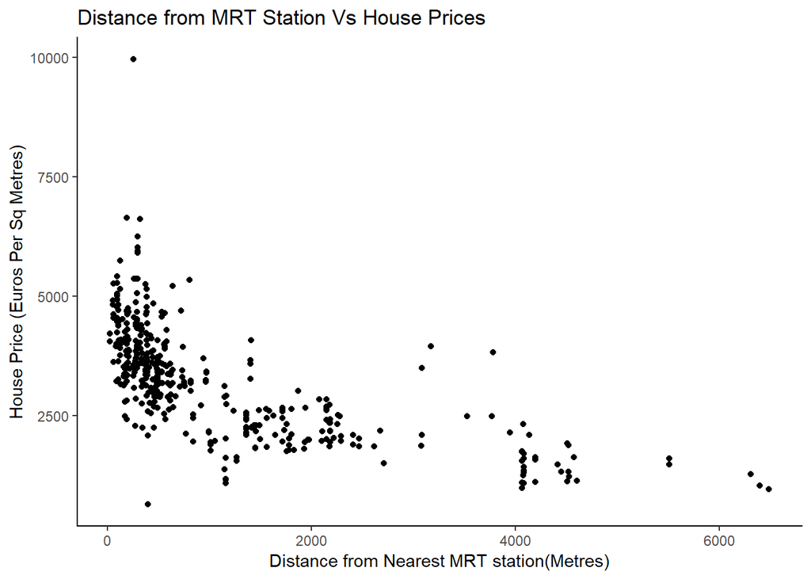

Scatter plot clearly shows that **houses closer to MRT stations have comparatively higher prices.** Hence the houses near MRT station have higher price on an average than overall city average.

## visualizing the House Prices and age of the house using a scatter plot

### Does age of the house relates to the price of the house?

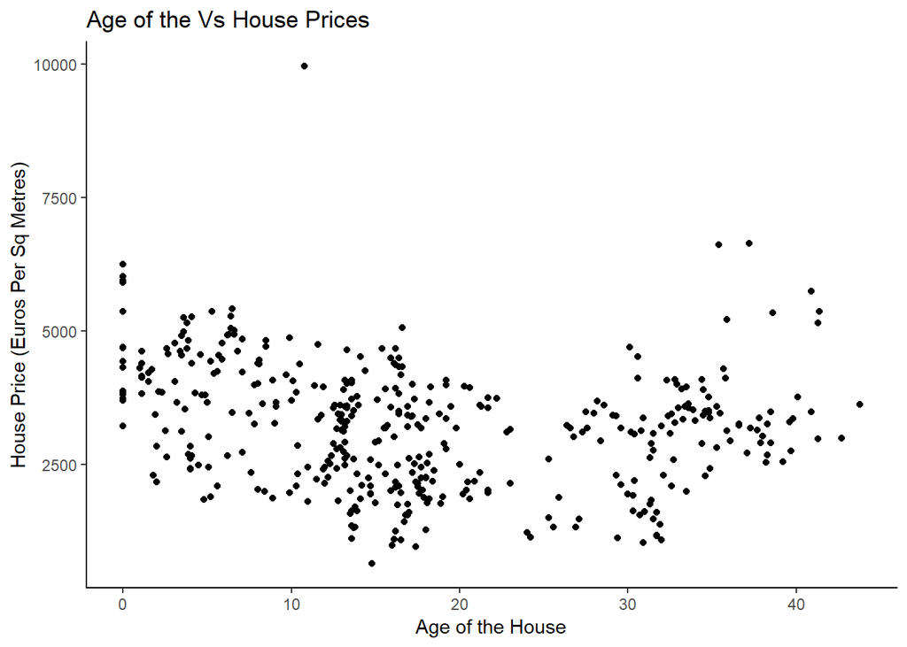

### Age of the top 5 costliest properties which are not newly built

[figure not shown]

### Regression Analysis

#### Analyse Output/Predictor column

Box plot of the House Prices

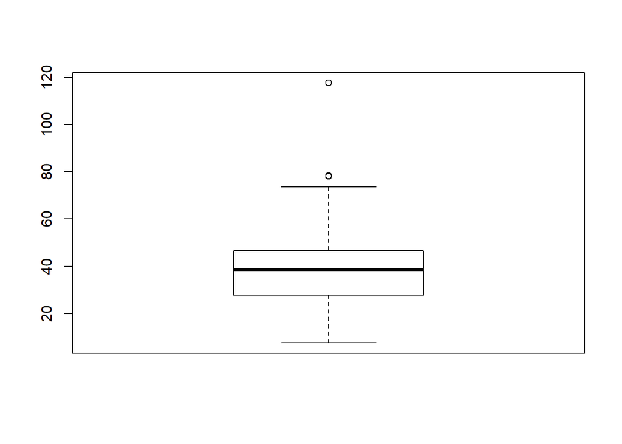

**Note:** there are few outliers, performing further analysis on whether to remove outlier or not.

#### Plotting a scatterplot with regression line to visualize position of outlier

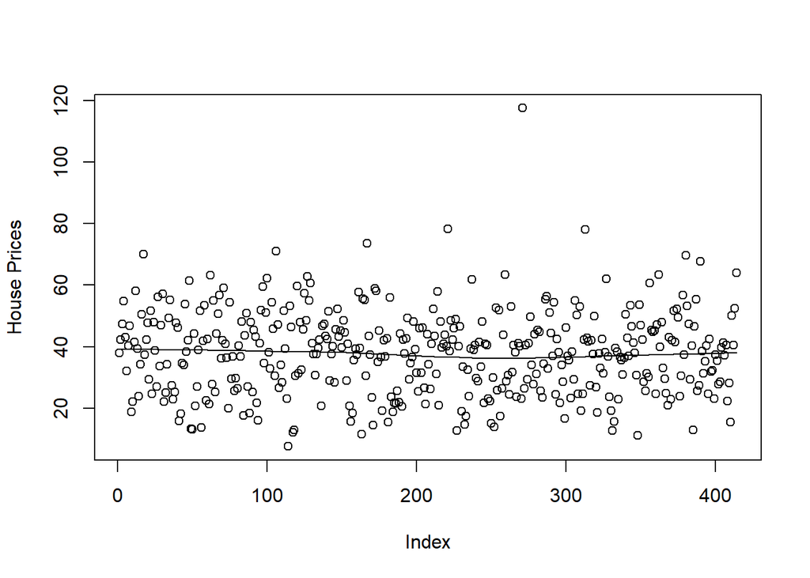

Scatterplot clearly shows the outlier will not impact the regression line but will only increase the residuals and can be removed.  
Adjusted r square is **0.566** which suggest its not a great model

Adjusted r square for the model is greatly increased from **0.566** to **0.612** and hence removal of the record was correct decision.

#### Visualizing the scatterplot again to verify the regression line.

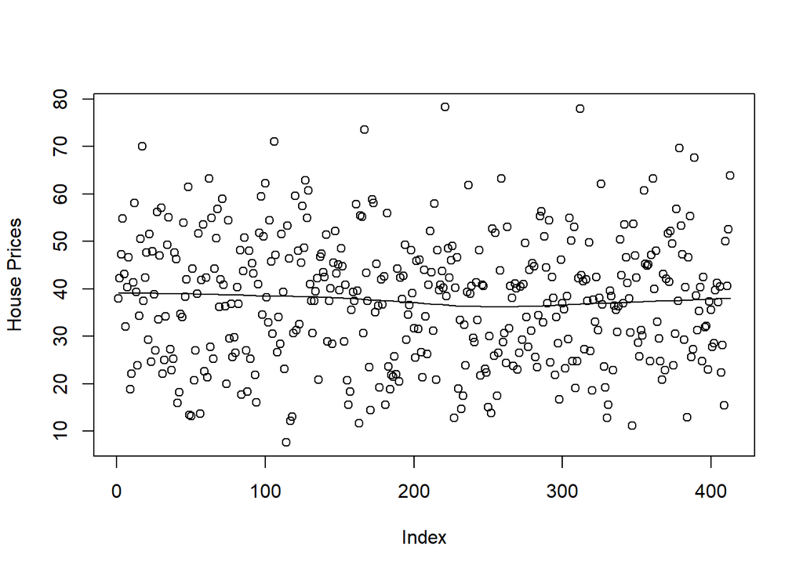

Slope of regression is line not impacted.

#### Hypotheis

**NULL Hypothesis H0:** There is no relationship between Dependent and Independent variables  
**Alternate Hypothesis H1:** There is a relationship between Dependent and Independent variables

#### Initial Model

Creating a regression model first using all columns and view the adjusted r squared statistics for the model.

Adjusted r squared (**0.62**) is bit low, the more the value of adjusted r square better will be the model.

### MODEL OPTIMIZATION

#### Adding Non Linear Relationships

By default linear regression assumes linear relationship, which is not the case for each feature. For example age of the house can have a non linear relationship. (Optimizing the model and then taking a deeper look into various model statistics.)

#### Step Backward Optimization

```
## Start:  AIC=1390.83
## Y_HousePrice ~ Age + MRTDist + NoStores + Lat + Long
##
##            Df Sum of Sq   RSS    AIC
## - Long      1     27.33 21355 1389.2
## <none>                  21328 1390.8
## - MRTDist   1   1491.66 22819 1411.2
## - Lat       1   1860.62 23188 1416.5
## - NoStores  1   2995.98 24324 1432.3
## - Age       1   3122.04 24450 1434.0
##
## Step:  AIC=1389.25
## Y_HousePrice ~ Age + MRTDist + NoStores + Lat
##
##            Df Sum of Sq   RSS    AIC
## <none>                  21355 1389.2
## - Lat       1    1833.3 23188 1414.5
## - NoStores  1    2975.3 24330 1430.4
## - Age       1    3129.3 24484 1432.5
## - MRTDist   1    3806.2 25161 1441.5
```

Increase in Adjusted R squared value(**0.67**) signifies an increase in accuracy of the model. Further improving accuracy by taking into account interactions.

#### Adding Interactions and Non Linear relationship for enhanced model

There is a possibility of interaction between location of house (latitude and longitude) and distance from MRT station and hence taking interactions into account.

```
##
## Call:
## lm(formula = Y_HousePrice ~ Age + Age_2 + MRTDist * Lat * Long +
##     NoStores, data = train.data)
##
## Residuals:
##     Min      1Q  Median      3Q     Max
## -30.276  -3.892  -0.102   3.552  35.134
##
## Coefficients: (2 not defined because of singularities)
##                    Estimate Std. Error t value Pr(>|t|)
## (Intercept)      -3.451e+04  7.196e+03  -4.796 2.48e-06 ***
## Age              -1.169e+00  1.373e-01  -8.515 6.47e-16 ***
## Age_2             2.203e-02  3.303e-03   6.671 1.11e-10 ***
## MRTDist           1.286e+01  2.266e+00   5.678 3.04e-08 ***
## Lat               3.956e+02  5.872e+01   6.738 7.42e-11 ***
## Long              2.031e+02  5.993e+01   3.389 0.000788 ***
## NoStores          7.147e-01  1.894e-01   3.773 0.000192 ***
## MRTDist:Lat      -1.101e-01  3.279e-02  -3.357 0.000883 ***
## MRTDist:Long     -8.328e-02  1.994e-02  -4.177 3.80e-05 ***
## Lat:Long                 NA         NA      NA       NA
## MRTDist:Lat:Long         NA         NA      NA       NA
## ---
## Signif. codes:  0 '***' 0.001 '**' 0.01 '*' 0.05 '.' 0.1 ' ' 1
##
## Residual standard error: 7.095 on 322 degrees of freedom
## Multiple R-squared:  0.7156, Adjusted R-squared:  0.7086
## F-statistic: 101.3 on 8 and 322 DF,  p-value: < 2.2e-16
```

Increase in **Adjusted r squared** value indicates the improvement in model performance  
Also, overall **p-value** (less than 0.05) shows null hypothesis can be rejected and hence house price can be predicted using various columns.  
**F-Statistic** represent the relation between dependent and independent variable, higher the value stronger the relationship  
Above summary shows the features were significant in predicting House Prices. Three stars shows highly significant features while two or less stars shows less significant features.

### Understanding Summary in detail

Understanding each part of the summary in more details.

#### Is Hypothesis supported?

```
##                   Estimate   Std. Error   t value     Pr(>|t|)
## (Intercept)  -3.451402e+04 7.196156e+03 -4.796174 2.476662e-06
## Age          -1.169347e+00 1.373322e-01 -8.514735 6.469441e-16
## Age_2         2.203333e-02 3.302991e-03  6.670721 1.110435e-10
## MRTDist       1.286419e+01 2.265556e+00  5.678161 3.042361e-08
## Lat           3.956400e+02 5.871996e+01  6.737742 7.423703e-11
## Long          2.031183e+02 5.992779e+01  3.389385 7.875757e-04
## NoStores      7.146684e-01 1.893978e-01  3.773372 1.916753e-04
## MRTDist:Lat  -1.100881e-01 3.279451e-02 -3.356907 8.825835e-04
## MRTDist:Long -8.328481e-02 1.993798e-02 -4.177194 3.804844e-05
```

Output shows equation coefficients for each feature

First row shows the intercept or constant of the equation  
Next rows represent the slope of equation for each of the feature used in regression.

Various Columns represent following information.  
**Estimate:** Expected value for the slope of feature and intercept of the equation.  
**Std. Error:** Average variation from expected value  
**t value:** Statistics to show how many SD the estimated coefficient is from 0  
**Pr(>|t|):** p-Value, using 95% CI, if p-value is less than 0.05 reject null hypothesis

It can be observed that p-value (less than 0.05) and all columns are significant in predicting house prices.

#### How well model fits the data?

```
##     Min.  1st Qu.   Median     Mean  3rd Qu.     Max.
## -30.2759  -3.8920  -0.1016   0.0000   3.5522  35.1340
```

Minimum, maximum and other values represent value of error that can occur in the model. Residuals explain how well the model is fits the data. Residuals should be symmetrically distributed around 0. Visualizing the residual plot.

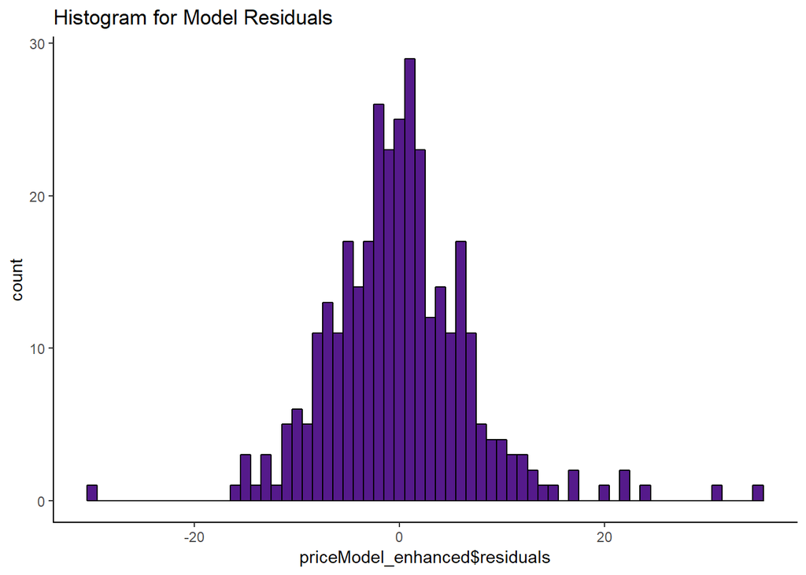

Histogram shows that residuals are evenly distributed around 0 and hence model is a good fit.

The RMSE is the square root of the variance of the residuals.  
Lower values of RMSE indicate better fit. RMSE is a good measure of how accurately the model predicts the response, and it is the most important criterion for fit if the main purpose of the model is prediction.

### Predicting prices

```r
predictPrice <- predict(priceModel_enhanced, test.data)
```

#### Plot Actual vs Predicted

Plot of actual vs predicted house prices represent how well the model performed in predicting house prices of test data set.

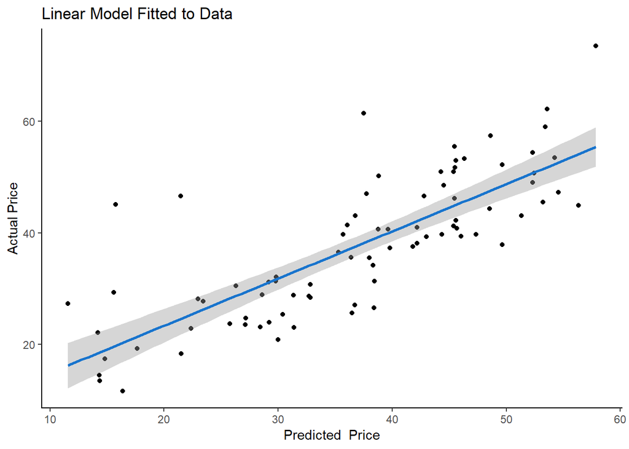

#### Evaluting residual plots for the model to analyse the fit

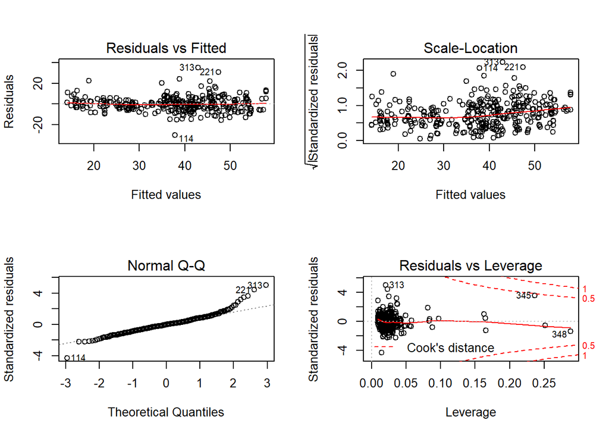

**Residuals Vs Fittedc** - Residuals are randomly distributed around horizontal line, no distinct trend in distribution is seen.  
**Normal QQ** - Residuals follow straight line with few exceptions and hence can be considered as normally distributed.  
**Scale Location** - Residuals are equally distributed along range of predictors. Hence homoscedasity is there.  
**Residuals vs Leverage** - No points exist on top right or bottom right corner i.e points with distance greater than 1 and hence model is good fit.